# Practical Machine Learning — Prediction Assignment Writeup

Robert Lowe

20 July 2015

### Loading the data

First we load the data (omitting row numbers in the first column, which will confuse the model since the observations are sorted by outcome). Many cells contain the text `#DIV/0!`; we treat these as missing values.

```r
pmlTraining <- read.csv(file = "pml-training.csv", na.strings = c("NA", "#DIV/0!"))[, 2:160]
pmlTesting <- read.csv(file = "pml-testing.csv", na.strings = c("NA", "#DIV/0!"))[, 2:160]
```

From visual inspection of the data it’s apparent that many variables have mostly `NA` values. Let’s look at the proportion of `NA` values for each variable.

```r
avgNA <- apply(pmlTraining, 2, function(v) { mean(is.na(v))  })
avgNA
```

```
##                user_name     raw_timestamp_part_1     raw_timestamp_part_2
##                0.0000000                0.0000000                0.0000000
##           cvtd_timestamp               new_window               num_window
##                0.0000000                0.0000000                0.0000000
##                roll_belt               pitch_belt                 yaw_belt
##                0.0000000                0.0000000                0.0000000
##         total_accel_belt       kurtosis_roll_belt      kurtosis_picth_belt
##                0.0000000                0.9798186                0.9809398
##        kurtosis_yaw_belt       skewness_roll_belt     skewness_roll_belt.1
##                1.0000000                0.9797676                0.9809398
##        skewness_yaw_belt            max_roll_belt           max_picth_belt
##                1.0000000                0.9793089                0.9793089
##             max_yaw_belt            min_roll_belt           min_pitch_belt
##                0.9798186                0.9793089                0.9793089
##             min_yaw_belt      amplitude_roll_belt     amplitude_pitch_belt
##                0.9798186                0.9793089                0.9793089
##       amplitude_yaw_belt     var_total_accel_belt            avg_roll_belt
##                0.9798186                0.9793089                0.9793089
##         stddev_roll_belt            var_roll_belt           avg_pitch_belt
##                0.9793089                0.9793089                0.9793089
##        stddev_pitch_belt           var_pitch_belt             avg_yaw_belt
##                0.9793089                0.9793089                0.9793089
##          stddev_yaw_belt             var_yaw_belt             gyros_belt_x
##                0.9793089                0.9793089                0.0000000
##             gyros_belt_y             gyros_belt_z             accel_belt_x
##                0.0000000                0.0000000                0.0000000
##             accel_belt_y             accel_belt_z            magnet_belt_x
##                0.0000000                0.0000000                0.0000000
##            magnet_belt_y            magnet_belt_z                 roll_arm
##                0.0000000                0.0000000                0.0000000
##                pitch_arm                  yaw_arm          total_accel_arm
##                0.0000000                0.0000000                0.0000000
##            var_accel_arm             avg_roll_arm          stddev_roll_arm
##                0.9793089                0.9793089                0.9793089
##             var_roll_arm            avg_pitch_arm         stddev_pitch_arm
##                0.9793089                0.9793089                0.9793089
##            var_pitch_arm              avg_yaw_arm           stddev_yaw_arm
##                0.9793089                0.9793089                0.9793089
##              var_yaw_arm              gyros_arm_x              gyros_arm_y
##                0.9793089                0.0000000                0.0000000
```

[output cut: 51 more lines]

```
##                0.9793089                0.9793089                0.9835898
##      total_accel_forearm        var_accel_forearm         avg_roll_forearm
##                0.0000000                0.9793089                0.9793089
##      stddev_roll_forearm         var_roll_forearm        avg_pitch_forearm
##                0.9793089                0.9793089                0.9793089
##     stddev_pitch_forearm        var_pitch_forearm          avg_yaw_forearm
##                0.9793089                0.9793089                0.9793089
##       stddev_yaw_forearm          var_yaw_forearm          gyros_forearm_x
##                0.9793089                0.9793089                0.0000000
##          gyros_forearm_y          gyros_forearm_z          accel_forearm_x
##                0.0000000                0.0000000                0.0000000
##          accel_forearm_y          accel_forearm_z         magnet_forearm_x
##                0.0000000                0.0000000                0.0000000
##         magnet_forearm_y         magnet_forearm_z                   classe
##                0.0000000                0.0000000                0.0000000
```

We’ll remove variables with more than 90% of the values missing.

```r
filteredTrain <- pmlTraining[, avgNA <= 0.9]
filteredTest <- pmlTesting[, avgNA <= 0.9]
```

### Creating dummy variables

Next we create dummy (numeric) variables from the factors.

```r
library(caret)
merged <- rbind(filteredTest[, -59], filteredTrain[, -59])
dummies <- dummyVars(~ ., data = merged)
dv <- as.data.frame(predict(dummies, newdata = merged))
pmldv <- dv[21:nrow(dv), ]
pmldvTest <- dv[1:20, ]
```

### Predictors with near zero-variance

We will ignore variables with near zero-variance.

```r
nzv <- nearZeroVar(pmldv)
filteredPredictors <- pmldv[, -nzv]
filteredPredictorsTest <- pmldvTest[, -nzv]
```

### Splitting the data

Now create training and cross-validation sets, preserving the overall class distribution.

```r
set.seed(745363615)
inTrain <- createDataPartition(y = pmlTraining$classe, p = 0.75, list = FALSE)
trainPredictors <- filteredPredictors[inTrain, ]
cvPredictors <- filteredPredictors[-inTrain, ]
```

### Principal components

We plot the observations in the training set against the first two principal components. We find clear clusters in the observations, however these clusters don’t appear to correspond with the exercise classes.

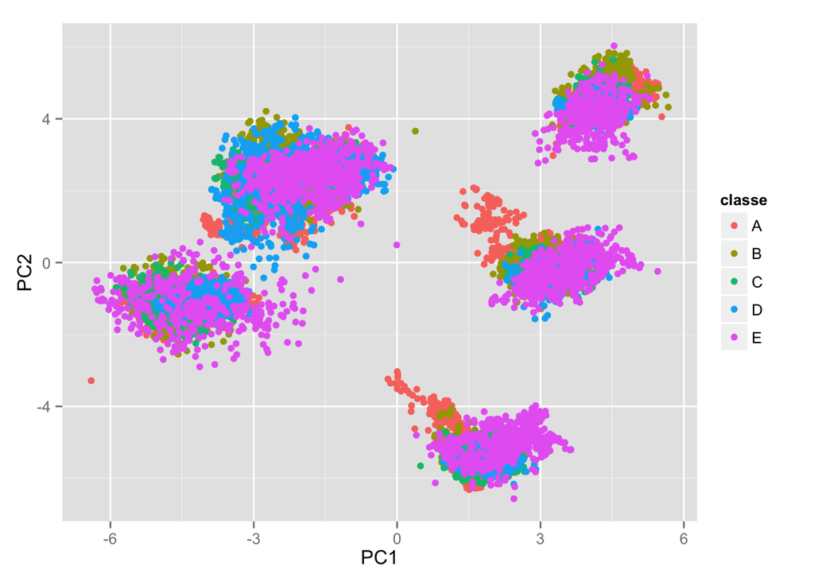

```r
preProcValues <- preProcess(x = trainPredictors, method = "pca", pcaComp = 2)
trainPCA <- predict(preProcValues, trainPredictors)
plotdata <- data.frame(trainPCA,
                       classe = pmlTraining$classe[inTrain],
                       user_name = pmlTraining$user_name[inTrain])
ggplot(data = plotdata, mapping = aes(x = PC1, y = PC2, colour = classe)) + geom_point()
```

The plot below shows that the clusters actually correspond with `user_name`.

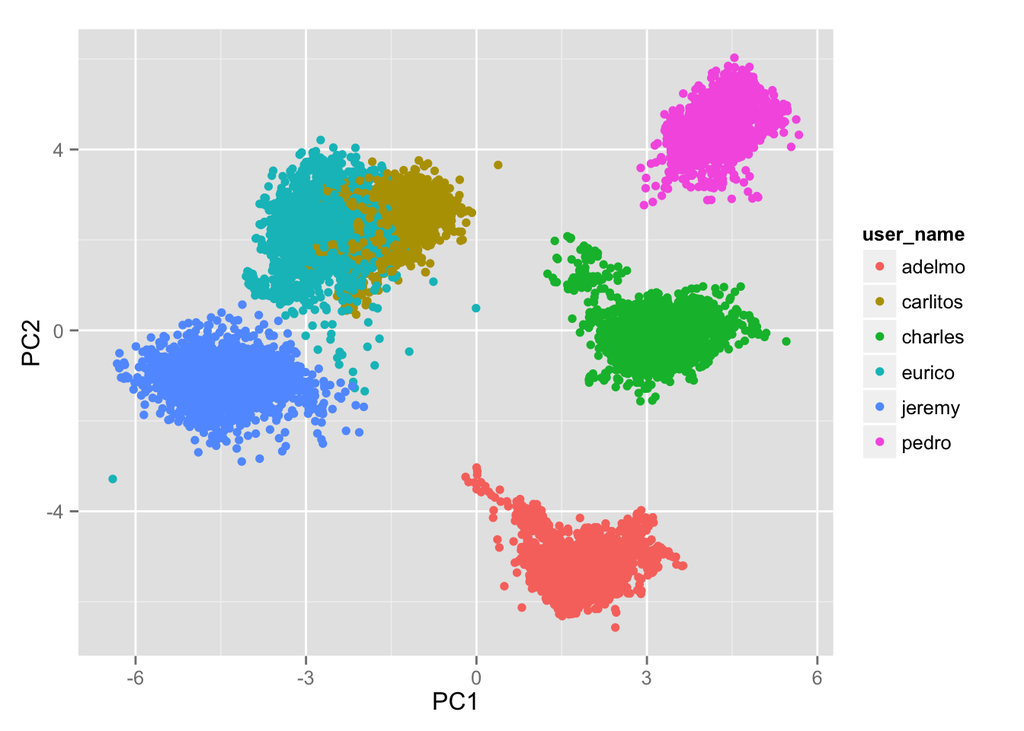

```r
ggplot(data = plotdata, mapping = aes(x = PC1, y = PC2, colour = user_name)) + geom_point()
```

So it appears fairly straightforward to distinguish the observations based on `user_name`, but it might be harder distinguish the observations based on exercise class.

### A CART model

We fit a CART model.

[figure not shown]

```r
training <- data.frame(trainPredictors, classe = pmlTraining$classe[inTrain])
cv <- data.frame(cvPredictors, classe = pmlTraining$classe[-inTrain])
cart <- train(form = classe ~ ., data = training, method = "rpart")
library(rattle)
fancyRpartPlot(cart$finalModel)
```

```r
trainCM <- confusionMatrix(data = predict(cart, newdata = training), reference = training$classe)
trainCM
```

```
## Confusion Matrix and Statistics
##
##           Reference
## Prediction    A    B    C    D    E
##          A 2732  301    2    0    0
##          B  533 1025  275  632  151
##          C  909 1522 2290 1780 1341
##          D    0    0    0    0    0
##          E   11    0    0    0 1214
##
## Overall Statistics
##
##                Accuracy : 0.4933
##                  95% CI : (0.4852, 0.5015)
##     No Information Rate : 0.2843
##     P-Value [Acc > NIR] : < 2.2e-16
##
##                   Kappa : 0.3657
##  Mcnemar's Test P-Value : NA
##
## Statistics by Class:
##
##                      Class: A Class: B Class: C Class: D Class: E
## Sensitivity            0.6528  0.35990   0.8921   0.0000  0.44863
## Specificity            0.9712  0.86596   0.5431   1.0000  0.99908
## Pos Pred Value         0.9002  0.39182   0.2920      NaN  0.99102
## Neg Pred Value         0.8756  0.84936   0.9597   0.8361  0.88942
## Prevalence             0.2843  0.19350   0.1744   0.1639  0.18386
## Detection Rate         0.1856  0.06964   0.1556   0.0000  0.08248
## Detection Prevalence   0.2062  0.17774   0.5328   0.0000  0.08323
## Balanced Accuracy      0.8120  0.61293   0.7176   0.5000  0.72386
```

```r
cvCM <- confusionMatrix(data = predict(cart, newdata = cv), reference = cv$classe)
cvCM
```

```
## Confusion Matrix and Statistics
##
##           Reference
## Prediction   A   B   C   D   E
##          A 905  86   0   0   0
##          B 185 353  98 218  45
##          C 302 510 757 586 439
##          D   0   0   0   0   0
##          E   3   0   0   0 417
##
## Overall Statistics
##
##                Accuracy : 0.4959
##                  95% CI : (0.4818, 0.51)
##     No Information Rate : 0.2845
##     P-Value [Acc > NIR] : < 2.2e-16
##
##                   Kappa : 0.3692
##  Mcnemar's Test P-Value : NA
##
## Statistics by Class:
##
##                      Class: A Class: B Class: C Class: D Class: E
## Sensitivity            0.6487  0.37197   0.8854   0.0000  0.46282
## Specificity            0.9755  0.86195   0.5463   1.0000  0.99925
## Pos Pred Value         0.9132  0.39266   0.2918      NaN  0.99286
## Neg Pred Value         0.8748  0.85119   0.9576   0.8361  0.89206
## Prevalence             0.2845  0.19352   0.1743   0.1639  0.18373
## Detection Rate         0.1845  0.07198   0.1544   0.0000  0.08503
## Detection Prevalence   0.2021  0.18332   0.5290   0.0000  0.08564
## Balanced Accuracy      0.8121  0.61696   0.7158   0.5000  0.73103
```

The in sample error for the CART model is 0.507, and the out of sample error (as determined by cross-validation) is 0.504. Hopefully we can do better.

### A random forest

Let’s try a random forest.

```r
# This takes several hours, so used cached model if available
getForest <- function(name) {
  if (file.exists(name)) {
    readRDS(file = name)
  } else {
    result <- train(form = classe ~ ., data = training, method = "rf")
    saveRDS(object = result, file = name)
    result
  }
}
forest <- getForest("forest.rds")
trainCM <- confusionMatrix(data = predict(forest, newdata = training), reference = training$classe)
trainCM
```

```
## Confusion Matrix and Statistics
##
##           Reference
## Prediction    A    B    C    D    E
##          A 4185    0    0    0    0
##          B    0 2848    0    0    0
##          C    0    0 2567    0    0
##          D    0    0    0 2412    0
##          E    0    0    0    0 2706
##
## Overall Statistics
##
##                Accuracy : 1
##                  95% CI : (0.9997, 1)
##     No Information Rate : 0.2843
##     P-Value [Acc > NIR] : < 2.2e-16
##
##                   Kappa : 1
##  Mcnemar's Test P-Value : NA
##
## Statistics by Class:
##
##                      Class: A Class: B Class: C Class: D Class: E
## Sensitivity            1.0000   1.0000   1.0000   1.0000   1.0000
## Specificity            1.0000   1.0000   1.0000   1.0000   1.0000
## Pos Pred Value         1.0000   1.0000   1.0000   1.0000   1.0000
## Neg Pred Value         1.0000   1.0000   1.0000   1.0000   1.0000
## Prevalence             0.2843   0.1935   0.1744   0.1639   0.1839
## Detection Rate         0.2843   0.1935   0.1744   0.1639   0.1839
## Detection Prevalence   0.2843   0.1935   0.1744   0.1639   0.1839
## Balanced Accuracy      1.0000   1.0000   1.0000   1.0000   1.0000
```

```r
cvCM <- confusionMatrix(data = predict(forest, newdata = cv), reference = cv$classe)
cvCM
```

```
## Confusion Matrix and Statistics
##
##           Reference
## Prediction    A    B    C    D    E
##          A 1395    0    0    0    0
##          B    0  949    2    0    0
##          C    0    0  853    1    0
##          D    0    0    0  803    0
##          E    0    0    0    0  901
##
## Overall Statistics
##
##                Accuracy : 0.9994
##                  95% CI : (0.9982, 0.9999)
##     No Information Rate : 0.2845
##     P-Value [Acc > NIR] : < 2.2e-16
##
##                   Kappa : 0.9992
##  Mcnemar's Test P-Value : NA
##
## Statistics by Class:
##
##                      Class: A Class: B Class: C Class: D Class: E
## Sensitivity            1.0000   1.0000   0.9977   0.9988   1.0000
## Specificity            1.0000   0.9995   0.9998   1.0000   1.0000
## Pos Pred Value         1.0000   0.9979   0.9988   1.0000   1.0000
## Neg Pred Value         1.0000   1.0000   0.9995   0.9998   1.0000
## Prevalence             0.2845   0.1935   0.1743   0.1639   0.1837
## Detection Rate         0.2845   0.1935   0.1739   0.1637   0.1837
## Detection Prevalence   0.2845   0.1939   0.1741   0.1637   0.1837
## Balanced Accuracy      1.0000   0.9997   0.9987   0.9994   1.0000
```